# climate change at DuckDuckGo

## ['Extrapolations' review: The screenwriter of 'Contagion' takes on climate change and the future](https://www.msn.com/en-us/travel/news/extrapolations-review-the-screenwriter-of-contagion-takes-on-climate-change-and-the-future/ar-AA18Ic6v)

[Chicago Tribune on MSN.com](https://www.msn.com/en-us/travel/news/extrapolations-review-the-screenwriter-of-contagion-takes-on-climate-change-and-the-future/ar-AA18Ic6v)|15 hours ago

What might our lives look like decades from now, when the effects of **climate** **change** have progressed even further? That's the premise of "Extrapolations," Apple TV+'s star-studded series from Scott Z.

## [Waste pickers collect food waste, help combat climate change](https://www.chron.com/news/world/article/waste-pickers-collect-food-waste-help-combat-17844491.php)

[Houston Chronicle](https://www.chron.com/news/world/article/waste-pickers-collect-food-waste-help-combat-17844491.php)|5 hours ago

She places the food waste in a designated container so it can be turned to compost at the local recycling facility. The rest of the waste goes into separate containers and the recyclables are later sold.

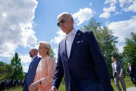

## [How Climate Change Became Central to U.S.-Europe Relations](https://news.yahoo.com/climate-change-became-central-u-212347139.html)

[YAHOO!News](https://news.yahoo.com/climate-change-became-central-u-212347139.html)|8 days ago

The meeting between Biden and his E.U. counterpart on March 10 could pave the way forward for constructive trans-Atlantic **climate** cooperation.

## [Climate change](https://www.msn.com/en-xl/news/other/climate-change/ar-AA18Eg2K)

[The Nation on MSN.com](https://www.msn.com/en-xl/news/other/climate-change/ar-AA18Eg2K)|2 days ago

**Climate** **change** in Pakistan is a major issue for the country. Pakistan is highly vulnerable to **climate** **change**. As with the changing **climate** in South Asia as a whole, the **climate** of Pakistan has changed over the past decade,

## [Climate change creates 'win-win' for bald eagles and farmers](https://www.eurekalert.org/news-releases/983043)

[EurekAlert!](https://www.eurekalert.org/news-releases/983043)|11 hours ago

ITHACA, N.Y. - As they seek new foods because **climate** **change** has altered their traditional diet of salmon carcasses, bald eagles in northwestern Washington state have become a boon to dairy farmers, deterring pests and removing animal carcasses from ...

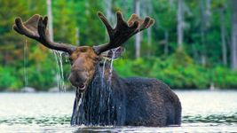

## [Researchers identify this mammal as latest potential cause of climate change, suggest balancing species](https://www.foxnews.com/politics/researchers-identify-mammal-latest-potential-cause-climate-change-suggest-balancing-species)

[Fox News](https://www.foxnews.com/politics/researchers-identify-mammal-latest-potential-cause-climate-change-suggest-balancing-species)|4 days ago

Researchers claim that moose are potentially a leading cause of **climate** **change** and that the species should be balanced, suggesting they are "one of the biggest potential single sources of carbon ...

## [Op/Ed: Push partisan politics to the side to create bipartisan solutions to climate change](https://www.indystar.com/story/opinion/2023/03/04/bipartisan-cooperation-needed-to-resolve-climate-change-in-u-s/69968497007/)

[The Indianapolis Star](https://www.indystar.com/story/opinion/2023/03/04/bipartisan-cooperation-needed-to-resolve-climate-change-in-u-s/69968497007/)|2 days ago

As we see it, this must include **climate** **change**. **Climate** instability is worsening, and Americans are facing escalating costs from extreme storms and other **climate** damages. Our generation — which ...

## [How Farms (and Their Wild Pollinators) Can Survive the Stress of Climate Change](https://www.yesmagazine.org/environment/2023/03/08/wild-pollinators-climate-change)

[YES! Magazine](https://www.yesmagazine.org/environment/2023/03/08/wild-pollinators-climate-change)|1 day ago

But farms like Birmingham's might help counter that trend at a time when **climate** **change** is accelerating the threat to species. Data show that the best **climate**-mitigating effect comes from a mosaic of landscape types, with more greenery producing greater ...

## [Scientists say climate change goosed New Zealand storm fury](https://www.sfgate.com/news/article/scientists-say-climate-change-goosed-new-zealand-17838000.php)

[SFGate](https://www.sfgate.com/news/article/scientists-say-climate-change-goosed-new-zealand-17838000.php)|3 days ago

**Climate** **change** worsened flooding from a tropical cyclone that shut down much of New Zealand last month in one of the country's costliest disasters, scientists said, but they couldn't quite ...

## [Climate change imperils the upper Mississippi River backwaters. Now nature needs human help.](https://www.jsonline.com/story/news/2023/03/03/fish-in-mississippi-river-backwaters-are-at-risk-due-to-climate-change/69881025007/)

[Milwaukee Journal Sentinel](https://www.jsonline.com/story/news/2023/03/03/fish-in-mississippi-river-backwaters-are-at-risk-due-to-climate-change/69881025007/)|3 days ago

The zone makes up just 3% to 5% of the total upper river area. **Climate** **change** is making the backwaters less habitable, and making the Goldilocks Zones inside of them even harder to find.

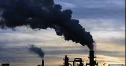

## [Sovereign wealth funds more committed to fighting climate change, survey says](https://www.pionline.com/esg/sovereign-wealth-funds-more-committed-fighting-climate-change-survey-says)

[Pensions&Investments](https://www.pionline.com/esg/sovereign-wealth-funds-more-committed-fighting-climate-change-survey-says)|1 day ago

Sovereign wealth funds are increasingly recognizing **climate** **change** as being part of their mandate and investing more in renewables.

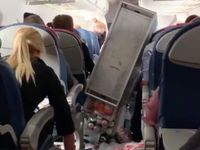

## [Climate change is making plane turbulence worse, and it could make flights bumpier and more expensive](https://news.yahoo.com/climate-change-making-plane-turbulence-123300402.html)

[Yahoo News](https://news.yahoo.com/climate-change-making-plane-turbulence-123300402.html)|6 days ago

You may experience more turbulence on future flights, especially transatlantic routes. **Climate** **change** has altered the jet stream and led to more unpredictable clear-air turbulence. For a safe flight, experts say to stay seated when the seatbelt light is on ...

## [UCP holds two-day int'l conference on climate change challenges and responses](https://www.msn.com/en-xl/news/other/ucp-holds-two-day-intl-conference-on-climate-change-challenges-and-responses/ar-AA18HDl7)

[The Nation on MSN.com](https://www.msn.com/en-xl/news/other/ucp-holds-two-day-intl-conference-on-climate-change-challenges-and-responses/ar-AA18HDl7)|20 hours ago

A two-day international conference on **climate** **change** challenges and responses has started at University of Central Punjab. Lahore High Court Judge Justice Jawad Hassan, guest of honors USAID's Deputy Mission Director Michael Rossman,

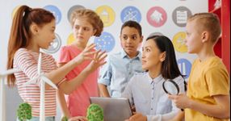

## [Blue states seek to mandate climate change lessons in public schools](https://www.washingtonexaminer.com/restoring-america/community-family/blue-states-seek-mandate-climate-change-lessons-public-schools)

[Washington Examiner](https://www.washingtonexaminer.com/restoring-america/community-family/blue-states-seek-mandate-climate-change-lessons-public-schools)|4 days ago

Democratic state lawmakers in Oregon, New York, and California have proposed bills that would require schools in their states to develop and implement a **climate** **change**-focused curriculum.

## [Supporters tout bill adding climate change to Washington's growth plan as way to reduce emissions](https://www.thecentersquare.com/washington/article_9a728340-c363-11ed-b41d-1f119b40b1f6.html)

[The Center Square](https://www.thecentersquare.com/washington/article_9a728340-c363-11ed-b41d-1f119b40b1f6.html)|1 day ago

Legislation that would add **climate** **change** resiliency as a goal to Washington state's Growth Management Act drew mostly supportive comments at Tuesday's public hearing before a

## [How AI can help combat climate change](https://hub.jhu.edu/2023/03/07/artificial-intelligence-combat-climate-change/)

[HUB](https://hub.jhu.edu/2023/03/07/artificial-intelligence-combat-climate-change/)|8 days ago

**Climate** **change** is a global emergency challenging scientists, engineers, and industry experts from a wide array of disciplines to use their knowledge and skills in pursuit of solutions to protect our planet. Not surprisingly, some of those solutions are ...

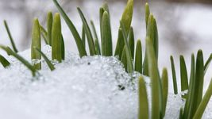

## [If April showers bring May flowers, why are blooms appearing so early? Climate change.](https://www.usatoday.com/story/news/2023/03/09/early-spring-2023-flower-blooms-show-climate-change-impact/11373671002/)

[USA Today](https://www.usatoday.com/story/news/2023/03/09/early-spring-2023-flower-blooms-show-climate-change-impact/11373671002/)|8 days ago

Daffodils, violets and other flowers are arriving early in many gardens and fields this spring, unfurling lovely colors and shedding light on how plants are adapting to **climate** **change**.

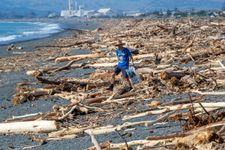

## [Climate change made New Zealand's Cyclone Gabrielle flooding 'four times more common'](https://www.independent.co.uk/climate-change/news/climate-change-cyclone-gabrielle-new-zealand-b2300138.html)

[The Independent](https://www.independent.co.uk/climate-change/news/climate-change-cyclone-gabrielle-new-zealand-b2300138.html)|2 days ago

**Climate** crisis "likely" played a role in exacerbating the heavy rainfall events that flooded northeast New Zealand following Cyclone Gabrielle, making such incidents "four times more common ...

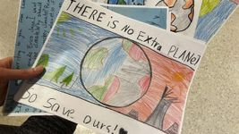

## [Oregon eyes mandate for climate change lessons in schools](https://www.foxnews.com/politics/oregon-eyes-mandate-climate-change-lessons-schools)

[Fox News](https://www.foxnews.com/politics/oregon-eyes-mandate-climate-change-lessons-schools)|5 days ago

Oregon lawmakers are aiming to make the state the second in the nation to mandate **climate** **change** lessons for K-12 public school students, further fueling U.S. culture wars in education.

## [Iraqi PM promises action to tackle crippling climate change](https://www.washingtonpost.com/world/2023/03/12/iraq-basra-climate-change/367354ee-c0cc-11ed-82a7-6a87555c1878_story.html)

[The Washington Post](https://www.washingtonpost.com/world/2023/03/12/iraq-basra-climate-change/367354ee-c0cc-11ed-82a7-6a87555c1878_story.html)|4 days ago

BAGHDAD — Iraq's prime minister Sunday promised sweeping measures to tackle **climate** **change** — which has affected millions across the country — including plans to meet a third of the country ...

## [Q&A: How AI can help combat climate change](https://phys.org/news/2023-03-qa-ai-combat-climate.html)

[Phys.org](https://phys.org/news/2023-03-qa-ai-combat-climate.html)|8 days ago

**Climate** **change** is a global emergency challenging scientists, engineers, and industry experts from a wide array of disciplines to use their knowledge and skills in pursuit of solutions to protect ...

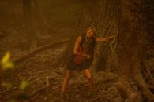

## [Extrapolations' Daveed Diggs talks 'wild, scary' climate change series](https://www.radiotimes.com/tv/drama/extrapolations-daveed-diggs-wild-scary-exclusive-newsupdate/)

[Radio Times](https://www.radiotimes.com/tv/drama/extrapolations-daveed-diggs-wild-scary-exclusive-newsupdate/)|15 hours ago

Diggs spoke exclusively with RadioTimes.com about the new star-studded Apple TV+ series. New Apple TV+ series Extrapolations charts the world's future from 2037 to 2070, exploring the effects that **climate** **change** is set to have on humanity as we go forward.

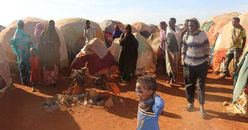

## [IOM says climate change fueling displacement in Horn of Africa](https://www.msn.com/en-ae/news/others/iom-says-climate-change-fueling-displacement-in-horn-of-africa/ar-AA18HlZr)

[XINHUA on MSN.com](https://www.msn.com/en-ae/news/others/iom-says-climate-change-fueling-displacement-in-horn-of-africa/ar-AA18HlZr)|20 hours ago

Displaced persons wait for food distribution from a local NGO in Baidoa district, Somalia, on Jan. 20, 2023. (Photo by Abdi/Xinhua) Over two million people have been internally displaced in Djibouti,

## [DRC Dilemma - Generate Oil Wealth or Combat Climate Change?](https://www.msn.com/en-xl/news/other/drc-dilemma-generate-oil-wealth-or-combat-climate-change/ar-AA18H9Ii)

[allAfrica.com on MSN.com](https://www.msn.com/en-xl/news/other/drc-dilemma-generate-oil-wealth-or-combat-climate-change/ar-AA18H9Ii)|22 hours ago

The Democratic Republic of Congo wants more money for **climate** projects. Otherwise, oil drilling could replace fishermen in the world's largest peat bog. And that could spell devastation for the environment.

[figure not shown]

## [Silicon Valley Bank Collapse Threatens Climate Start-Ups](https://www.nytimes.com/2023/03/12/climate/silicon-valley-bank-climate.html)

[The New York Times](https://www.nytimes.com/2023/03/12/climate/silicon-valley-bank-climate.html)|4 days ago

Anyone can read what you share. By David Gelles Gelles writes about business, **climate** **change** and public policy. As the fallout of the collapse of Silicon Valley Bank continued to spread over the ...

" The Federal Government has identified food insecurity, malnutrition as well as **climate** **change** as factors responsible for lower incomes and higher prices of foods in the country.It says the challenges have seriously put food out of the reach of many Nigerians.

## [Blow to Ruto as Parliamentary committee rejects nominee to climate change council](https://www.msn.com/en-xl/news/other/blow-to-ruto-as-parliamentary-committee-rejects-nominee-to-climate-change-council/ar-AA18Hjga)

[The Star on MSN.com](https://www.msn.com/en-xl/news/other/blow-to-ruto-as-parliamentary-committee-rejects-nominee-to-climate-change-council/ar-AA18Hjga)|22 hours ago

Umra's fate now lies with the plenary of the two Houses of Parliament.If the plenary rejects the committee recommendations, then she would land the job. President William Ruto has suffered a major blow after a Parliamentary committee rejected his nominee for the **Climate** **Change** Council.

## [India can face water woes due to effects of climate change: Avinash Mishra](https://www.msn.com/en-in/news/other/india-can-face-water-woes-due-to-effects-of-climate-change-avinash-mishra/ar-AA18ImuN)

[Hindustan Times on MSN.com](https://www.msn.com/en-in/news/other/india-can-face-water-woes-due-to-effects-of-climate-change-avinash-mishra/ar-AA18ImuN)|13 hours ago

There are a lot of problems in the way we conserve water and its distribution. India can face water woes in the future due to effects of **climate** **change**, says official

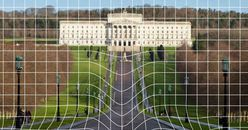

## [The Earth's Corr: Halving livestock may be only way to meet Northern Ireland climate change targets](https://www.msn.com/en-gb/money/other/the-earth-s-corr-halving-livestock-may-be-only-way-to-meet-northern-ireland-climate-change-targets/ar-AA18HAaY)

[Belfast Live on MSN.com](https://www.msn.com/en-gb/money/other/the-earth-s-corr-halving-livestock-may-be-only-way-to-meet-northern-ireland-climate-change-targets/ar-AA18HAaY)|21 hours ago

You can **change** your selection under 'Manage Preferences' at the bottom of this page. Privacy Statement. The UK **Climate** **Change** Committee's latest report on emissions reductions in Northern Ireland has cast serious doubts over our ability to deliver.

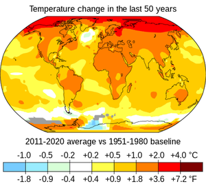

Climate change

In common usage, climate change describes global warming—the ongoing increase in global average temperature—and its effects on Earth's climate system. Climate change in a broader sense also includes previous long-term changes to Earth's climate.[Wikipedia](https://en.wikipedia.org/wiki/Climate_change)[More at Wikipedia](https://en.wikipedia.org/wiki/Climate_change)

[interactive chart not shown]